# Exercise 14.6.1

#### Time series plots

The visualizations above effectively illustrate that data no longer supports the Western versus developing world view. Once we see these plots, new questions emerge. For example, which countries are improving more and which ones less? Was the improvement constant during the last 50 years or was it more accelerated during certain periods? For a closer look that may help answer these questions, we introduce *time series plots*.

Time series plots have time in the x-axis and an outcome or measurement of interest on the y-axis. For example, here is a trend plot of United States fertility rates:

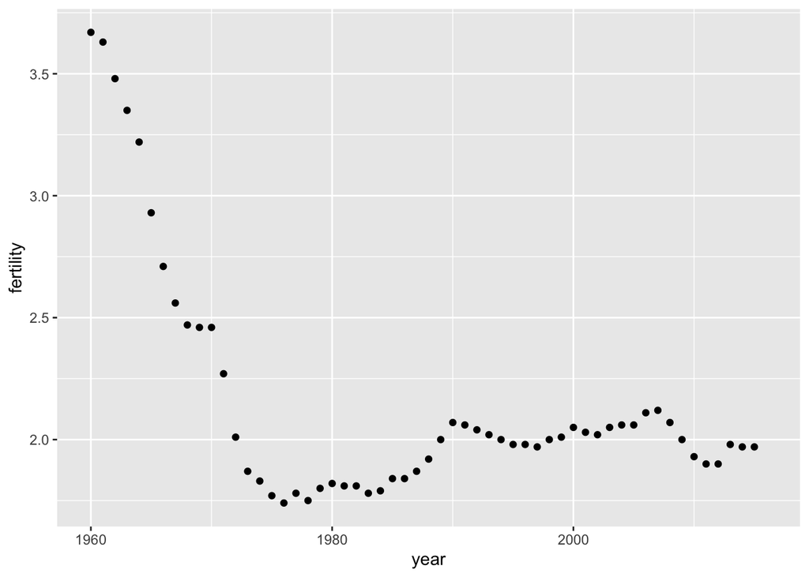

```r
gapminder %>%
  filter(country == "United States") %>%
  ggplot(aes(year, fertility)) +
  geom_point()
```

We see that the trend is not linear at all. Instead there is sharp drop during the 1960s and 1970s to below 2. Then the trend comes back to 2 and stabilizes during the 1990s.

When the points are regularly and densely spaced, as they are here, we create curves by joining the points with lines, to convey that these data are from a single series, here a country. To do this, we use the `geom_line` function instead of `geom_point`.

5. Make a lineplot showing the time series of fertility versus year for United States.

```r
# gapminder %>%
#   ___
```

6. Lineplots is particularly helpful when we look at more countries. Make a lineplot showing the time series of fertility versus year for South Korea and Germany. Use country as color aesthetic.

```r
countries <- c("South Korea", "Germany")
# gapminder %>% filter(country %in% ___) %>%
#   ggplot(aes(year, fertility, col = ___)) +
#   geom_line()
```

7. Make a lineplot showing the time series of life expectancy versus year for South Korea and Germany. Use country as color aesthetic.

```r
# gapminder %>%
#   ___
```

#### Data transformations

We now shift our attention to the second question related to the commonly held notion that wealth distribution across the world has become worse during the last decades. When general audiences are asked if poor countries have become poorer and rich countries become richer, the majority answers yes. By using stratification, histograms, smooth densities, and boxplots, we will be able to understand if this is in fact the case. First we learn how transformations can sometimes help provide more informative summaries and plots.

The `gapminder` data table includes a column with the countries’ gross domestic product (GDP). GDP measures the market value of goods and services produced by a country in a year. The GDP per person is often used as a rough summary of a country’s wealth. Here we divide this quantity by 365 to obtain the more interpretable measure *dollars per day*. Using current U.S. dollars as a unit, a person surviving on an income of less than $2 a day, is defined to be living in *absolute poverty*. We add this variable to the data table:

```r
gapminder <- gapminder %>%
  mutate(dollars_per_day = gdp/population/365)
```

The GDP values are adjusted for inflation and represent current U.S. dollar, so these values are meant to be comparable across the years. Of course, these are country averages and within each country there is much variability. All the graphs and insights described below relate to country averages and not to individuals.

Here is a histogram of per day incomes from 1970:

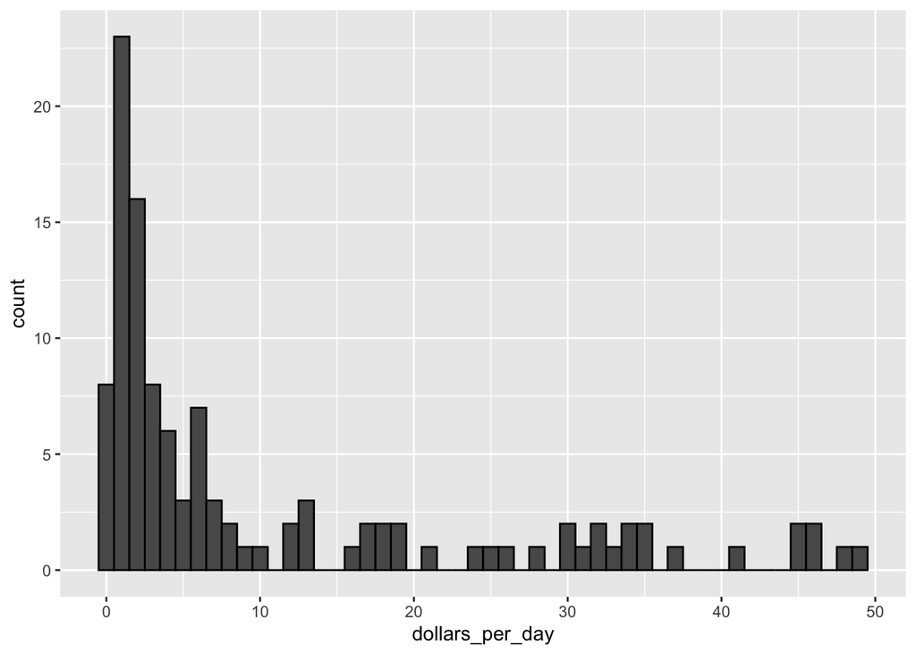

```r
past_year <- 1970
gapminder %>%
  filter(year == past_year & !is.na(gdp)) %>%
  ggplot(aes(dollars_per_day)) +
  geom_histogram(binwidth = 1, color = "black")
```

We use the `color = "black"` argument to draw a boundary and clearly distinguish the bins.

In this plot, we see that for the majority of countries, averages are below $10 a day. However, the majority of the x-axis is dedicated to the 35 countries with averages above $10. So the plot is not very informative about countries with values below $10 a day.

It might be more informative to quickly be able to see how many countries have average daily incomes of about $1 (extremely poor), $2 (very poor), $4 (poor), $8 (middle), $16 (well off), $32 (rich), $64 (very rich) per day. These changes are multiplicative and log transformations convert multiplicative changes into additive ones: when using base 2, a doubling of a value turns into an increase by 1.

8. Make a histogram of `log2(dollars_per_day)` from 1970.

```r
# gapminder %>%
#   ___
```

#### Infobox - Which base?

In the case above, we used base 2 in the log transformations. Other common choices are base $\mathrm{e}$ (the natural log) and base 10.

In general, we do not recommend using the natural log for data exploration and visualization. This is because while $2^2, 2^3, 2^4, \dots$ or $10^2, 10^3, \dots$ are easy to compute in our heads, the same is not true for $\mathrm{e}^2, \mathrm{e}^3, \dots$, so the scale is not intuitive or easy to interpret.

In the dollars per day example, we used base 2 instead of base 10 because the resulting range is easier to interpret. The range of the values being plotted is 0.3269426, 48.8852142.

In base 10, this turns into a range that includes very few integers: just 0 and 1. With base two, our range includes -2, -1, 0, 1, 2, 3, 4, and 5. It is easier to compute $2^x$ and $10^x$ when $x$ is an integer and between -10 and 10, so we prefer to have smaller integers in the scale. Another consequence of a limited range is that choosing the binwidth is more challenging. With log base 2, we know that a binwidth of 1 will translate to a bin with range $x$ to $2x$.

For an example in which base 10 makes more sense, consider population sizes. A log base 10 is preferable since the range for these is:

```r
filter(gapminder, year == past_year) %>%
  summarize(min = min(population), max = max(population))
```

```
##     min       max
## 1 46075 808510713
```

Here is the histogram of the transformed values:

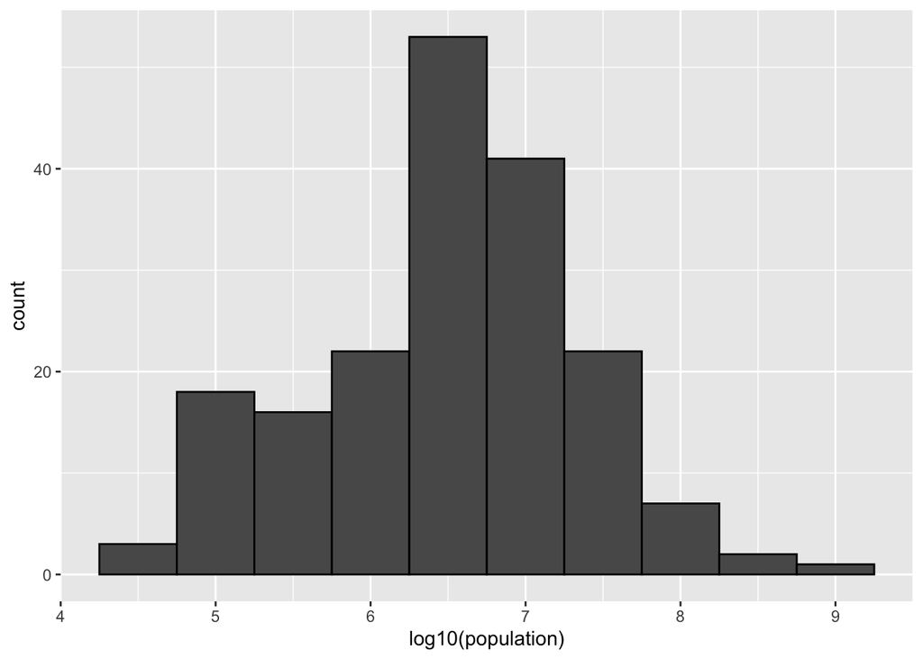

```r
gapminder %>%
  filter(year == past_year) %>%
  ggplot(aes(log10(population))) +
  geom_histogram(binwidth = 0.5, color = "black")
```

There are two ways we can use log transformations in plots. We can log the values before plotting them or use log scales on the axes. Both approaches are useful and have different strengths. If we log the data, we can more easily interpret intermediate values in the scale. For example, if we see:

`----1----x----2--------3----`

for log transformed data, we know that the value of $x$ is about 1.5. If the scales are logged:

`----1----x----10------100---`

then, to determine `x`, we need to compute $10^{1.5}$, which is not easy to do in our heads. The advantage of using logged scales is that we see the original values on the axes. However, the advantage of showing logged scales is that the original values are displayed in the plot, which are easier to interpret. For example, we would see “32 dollars a day” instead of “5 log base 2 dollars a day”.

9. Make a histogram of `dollars_per_day` from 1970 using a log2 scale on the x-axis. Compare it to the plot from Question 8. *Hint: you can use the `scale_x_continuous` function with `trans = "log2"`.*

```r
# gapminder %>%
#   ___
#   scale_x_continuous(trans = "log2")
```

The histograms in Questions 8 and 9 have two *bumps*: one at about 4 and another at about 32. In statistics these bumps are sometimes referred to as *modes*. The mode of a distribution is the value with the highest frequency. The mode of the normal distribution is the average. When a distribution, like the one above, does not monotonically decrease from the mode, we call the locations where it goes up and down again *local modes* and say that the distribution has *multiple modes* indicating different distributions for different groups.

The histogram above suggests that the 1970 country income distribution has two modes: one at about 2 dollars per day (1 in the log 2 scale) and another at about 32 dollars per day (5 in the log 2 scale). However, the histogram does not show us if the two groups of countries are *west* versus the *rest*. Let us create the `group` column:

```r
gapminder <- gapminder %>%
  mutate(group = case_when(
    region %in% c("Western Europe", "Northern Europe","Southern Europe",
                  "Northern America", "Australia and New Zealand") ~ "West",
    TRUE ~ "Rest")) %>%
  as_tibble()
```

10. Make a histogram of `dollars_per_day` from 1970 using a log2 scale and *facet* it by group. Is there a *west* versus the *rest* dichotomy?

The exploratory data analysis above has revealed two characteristics about average income distribution in 1970. Using a histogram, we found a bimodal distribution with the modes relating to poor and rich countries. We will try to visualize these summaries in one plot.

```r
# gapminder %>%
#   filter(year == past_year & !is.na(gdp)) %>%
#   ggplot(aes(dollars_per_day)) +
#   geom_histogram(binwidth = 1, color = "black") +
#   facet_grid(cols = ___) +
#   scale_x_continuous(trans = "log2")
```

11. Make a boxplot (`geom_boxplot`) of `dollars_per_day` (y-axis) versus `group` (x-axis) from 1970 using a log2 scale. Also add a the data using `geom_point()`.

```r
# gapminder %>%
#   filter(year == past_year & !is.na(gdp)) %>%
#   ggplot(aes(group, dollars_per_day)) +
#   geom____() +
#   scale_y_continuous(trans = "log2") +
#   geom____()
```

Data exploration clearly shows that in 1970 there was a “west versus the rest” dichotomy. But does this dichotomy persist? We first have to be a little careful here since there are more countries represented in 2010 than in 1970: the total counts are larger. One reason for this is that several countries were founded after 1970. For example, the Soviet Union divided into several countries during the 1990s. Another reason is that data was available for more countries in 2010. Hence we only have to consider the countries with data available for both years:

```r
past_year <- 1970
present_year <- 2010
years <- c(past_year, present_year)
country_list_1 <- gapminder %>%
  filter(year == past_year & !is.na(dollars_per_day)) %>%
  pull(country)

country_list_2 <- gapminder %>%
  filter(year == present_year & !is.na(dollars_per_day)) %>%
  pull(country)

country_list <- intersect(country_list_1, country_list_2)
```

We can now filter the rows by `years` and `country_list`.

12. Make a histogram of `dollars_per_day` from 1970 and 2010 using a log2 scale and *facet* it by group and year. Does the dichotomy persist?

```r
# gapminder %>%
#   filter(year %in% ___ & country %in% ___) %>%
#   ggplot(aes(dollars_per_day)) +
#   geom_histogram(binwidth = 1, color = "black") +
#   scale_x_continuous(trans = "log2") +
#   facet_grid(___)
```

13. Make a boxplot of `dollars_per_day` versus `group` from 1970 and 2010 using a log2 scale. Use year as fill aesthetic.

    *Hint: you must convert year to a factor using `mutate(year = factor(year))`.*

```r
# gapminder %>%
#   filter(year %in% years & country %in% country_list) %>%
#   mutate(year = factor(___)) %>%
#   ggplot(aes(group, dollars_per_day, fill = ___)) +
#   geom_boxplot() +
#   scale_y_continuous(trans = "log2")
```

The previous data exploration suggested that the income gap between rich and poor countries has narrowed considerably during the last 40 years. We used a series of histograms and boxplots to see this. Let us now shift to density plots. Let us start by noting that density plots for income distribution in 1970 and 2010 deliver the message that the gap is closing:

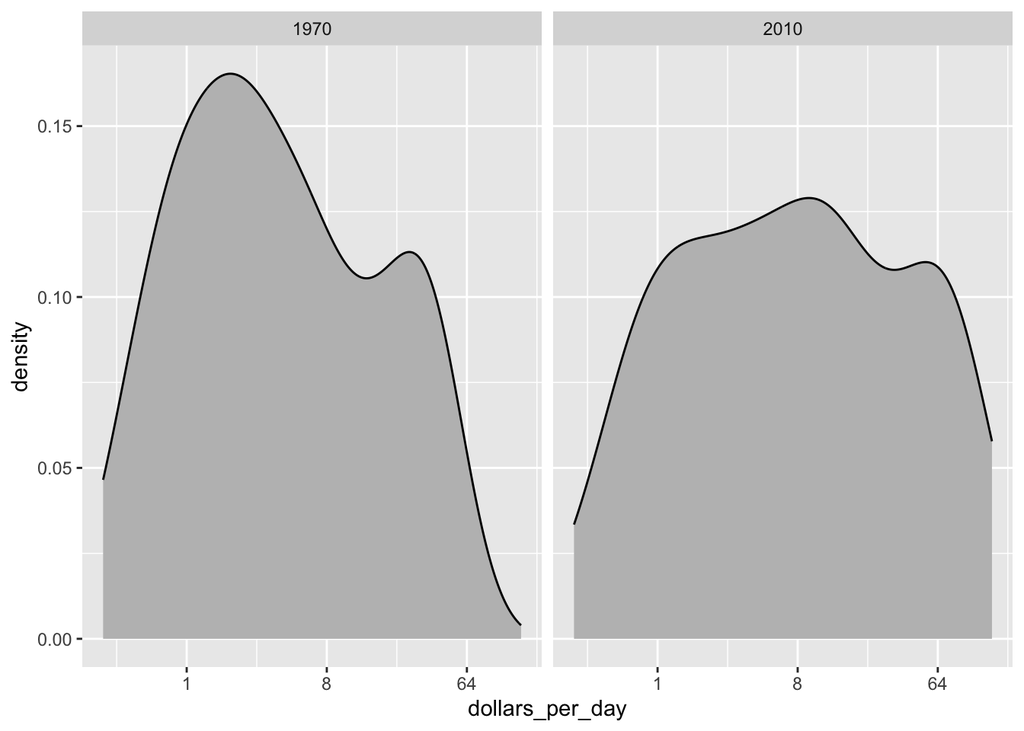

```r
gapminder %>%
  filter(year %in% years & country %in% country_list) %>%
  ggplot(aes(dollars_per_day)) +
  geom_density(fill = "grey") +
  scale_x_continuous(trans = "log2") +
  facet_grid(cols = vars(year))
```

In the 1970 plot, we see two clear modes: poor and rich countries. In 2010, it appears that some of the poor countries have shifted towards the right, closing the gap.

The next message we need to convey is that the reason for this change in distribution is that several poor countries became richer, rather than some rich countries becoming poorer. To do this, we can assign a color to the groups we identified during data exploration.

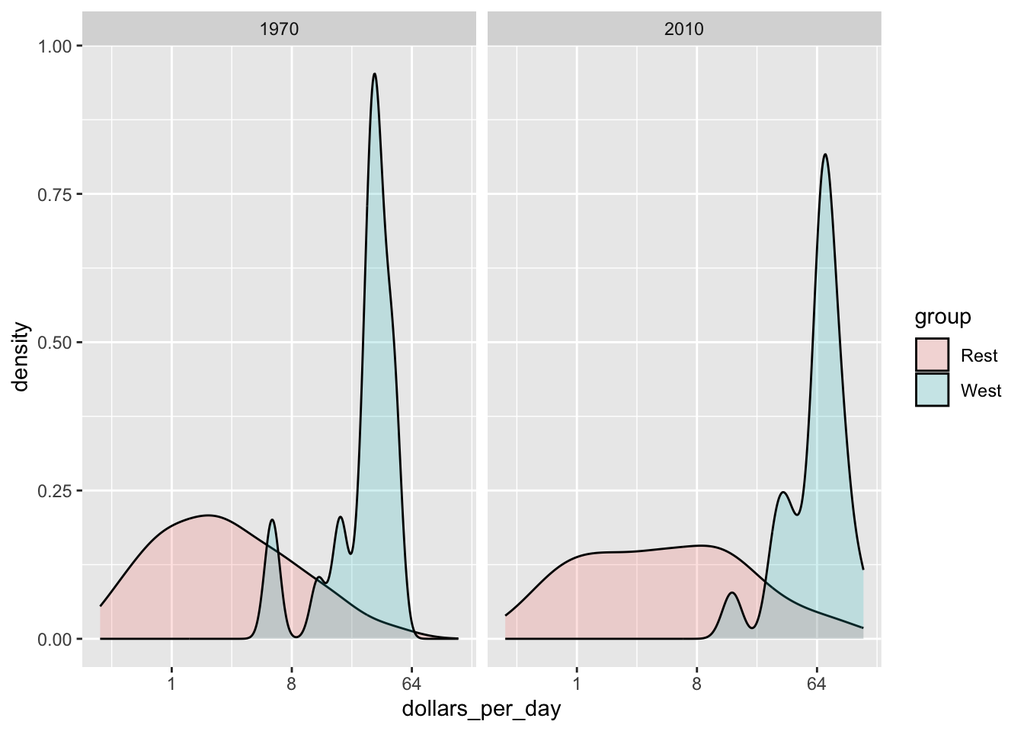

```r
gapminder %>%
  filter(year %in% years & country %in% country_list) %>%
  ggplot(aes(dollars_per_day, fill = group)) +
  scale_x_continuous(trans = "log2") +
  geom_density(alpha = 0.2) +
  facet_grid(cols = vars(year))
```

Note the default is to have the area represented by each distribution add up to 1, regardless of the size of each group: the number of countries in the ‘west’ group is 21 and in the ‘rest’ group is 87. We may use count on the y-axis instead:

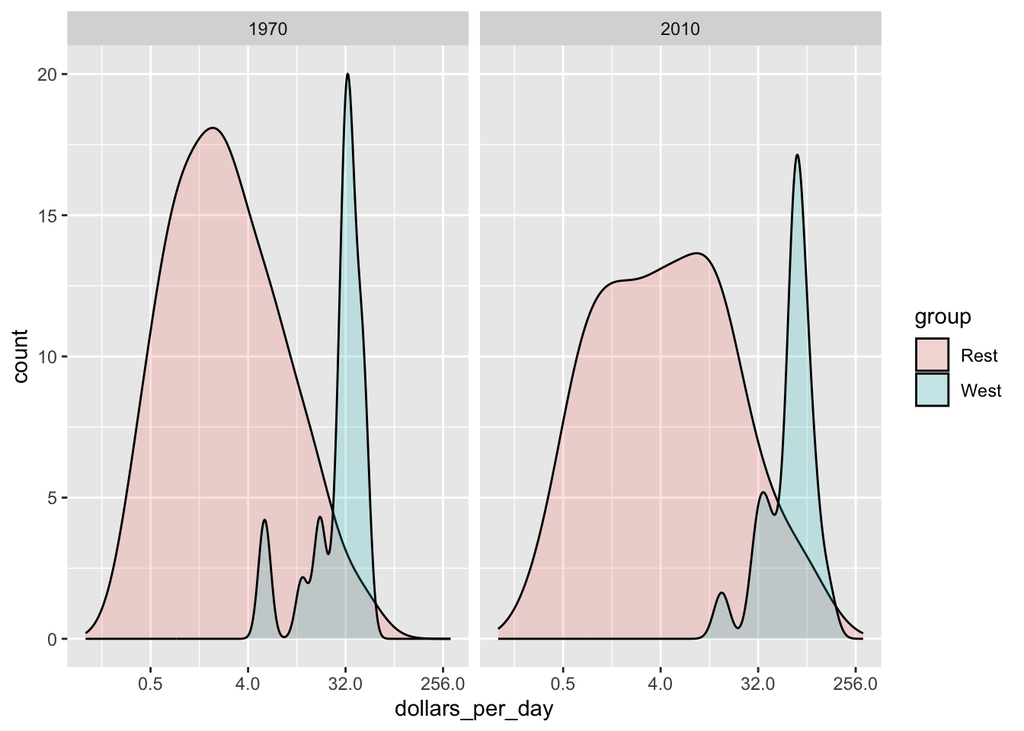

```r
p <- gapminder %>%
  filter(year %in% years & country %in% country_list) %>%
  ggplot(aes(dollars_per_day, y = ..count.., fill = group)) +
  scale_x_continuous(trans = "log2", limit = c(0.125, 300)) +
  facet_grid(cols = vars(year))
p + geom_density(alpha = 0.2)
```

14. To get densities smoother, use `bw = 0.75` argument so that the same bandwidth is used in each density. Comment on the plot.

```r
# p +
#   geom_density(alpha = 0.2, bw = ___)
```

As a final point, we note that in these distributions the weight of every country is the same. So if most of the population is improving, but living in a very large country, such as China, we might not appreciate this. We can actually weight the smooth densities using the `weight` mapping argument. We modify the dataset:

```r
gapminder <- gapminder %>%
  filter(year %in% years & country %in% country_list) %>%
  group_by(year) %>%
  mutate(weight = population/sum(population)*2) %>%
  ungroup()
```

15. Modify the ggplot function with a weight argument and plot the density (with area equal 1).

```r
# gapminder %>%
#   ggplot(aes(dollars_per_day, fill = group, weight = ___)) +
#   scale_x_continuous(trans = "log2", limit = c(0.125, 300)) +
#   geom_density(alpha = 0.2, bw = 0.75) +
#   facet_grid(cols = vars(year))
```

## Colophon

This report has been created inside [RStudio](http://www.rstudio.com/ide/) using [R Markdown](https://rmarkdown.rstudio.com/).

The report was built using:

```
##  setting  value
##  version  R version 4.2.2 (2022-10-31)
##  os       macOS Ventura 13.5.1
##  system   aarch64, darwin20
##  ui       X11
##  language (EN)
##  collate  en_US.UTF-8
##  ctype    en_US.UTF-8
##  tz       Europe/Copenhagen
##  date     2023-11-16
##  pandoc   3.1.1 @ /Applications/RStudio.app/Contents/Resources/app/quarto/bin/tools/ (via rmarkdown)
```